# Barbell lift quality prediction

## Assignment developed in the framework of the Practical Machine Learning course offered by Johns Hopkins University on Coursera.

[View on GitHub](https://github.com/jdestefani/pml-assignment) [Download .zip](https://github.com/jdestefani/pml-assignment/zipball/master) [Download .tar.gz](https://github.com/jdestefani/pml-assignment/tarball/master)

### Introduction

The assignment is based on the following paper by Velloso et al:

*Velloso, E.; Bulling, A.; Gellersen, H.; Ugulino, W.; Fuks, H.* **Qualitative Activity Recognition of Weight Lifting Exercises.** Proceedings of 4th International Conference in Cooperation with SIGCHI (Augmented Human '13) . Stuttgart, Germany: ACM SIGCHI, 2013. [Download](http://groupware.les.inf.puc-rio.br/public/papers/2013.Velloso.QAR-WLE.pdf)

In the project webpage , the authors describe their study as follows:

> Six young health participants were asked to perform one set of 10 repetitions of the Unilateral Dumbbell Biceps Curl in five different fashions: exactly according to the specification (Class A), throwing the elbows to the front (Class B), lifting the dumbbell only halfway (Class C), lowering the dumbbell only halfway (Class D) and throwing the hips to the front (Class E).  
> Class A corresponds to the specified execution of the exercise, while the other 4 classes correspond to common mistakes. Participants were supervised by an experienced weight lifter to make sure the execution complied to the manner they were supposed to simulate. The exercises were performed by six male participants aged between 20-28 years, with little weight lifting experience. We made sure that all participants could easily simulate the mistakes in a safe and controlled manner by using a relatively light dumbbell (1.25kg).

The dataset of the study, publicly available at http://groupware.les.inf.puc-rio.br/static/WLE/WearableComputing_weight_lifting_exercises_biceps_curl_variations.csv have been splitted by the course staff into a training set (pml-training.csv) of 19622 observations and a testing set (pml-testing.csv) of 20 observations.

The training and testing set have 160 variables including both the direct measurements from the arm, forearm, belt and dumbell sensors and derived measures computed on the aggregation of the aforementioned measurements in different time windows.

The goal of the assignment is to correctly predict the quality of the exercise (in a scale from A to E), given a single observation in the data frame.

### Data preprocessing

The original data available in the dataset needs some preprocessing before being actually used to build a predictive model. To be more precise, the original data contains several missing values, in the form of NA, empty strings or error messages (i.e "#DIV/0"). The first preprocessing step consists of transforming the heterogeneous missing values into a single missing value type, NA.

By observing carefully the dataset, one might notice that the derived variables display a prevalence of missing values, and actual values only for those rows corresponding to the end of the time window. The number of such rows is negligible (around 400 rows) compared to the size of the data set (19622 observation). For this reason, I considered the derived variable as irrelevant for the construction of the model and removed them from the dataset.

```r
 #Preprocessing training data
# Reading raw training data - 19622 observation of 160 variables
rawTrainingData <- read.csv("pml-training.csv");

# Find all the columns containing missing values (i.e. Na, "", "#DIV/0!") and normalize all the missing values to NA
missingValues <- sapply(rawTrainingData, function(x){x=="" || x=="#DIV/0!" || is.na(x)})
rawTrainingData[missingValues] <- NA

# Remove all the columns containing missing/sparse values - 19622 observation of 60 variables
missingValuesColumns <- ( grepl(glob2rx("^kurtosis*"),names(rawTrainingData))
                          | grepl(glob2rx("^skewness*"),names(rawTrainingData))
                          | grepl(glob2rx("^kurtosis*"),names(rawTrainingData))
                          | grepl(glob2rx("^avg*"),names(rawTrainingData))
                          | grepl(glob2rx("^var*"),names(rawTrainingData))
                          | grepl(glob2rx("^stddev*"),names(rawTrainingData))
                          | grepl(glob2rx("^max*"),names(rawTrainingData))
                          | grepl(glob2rx("^min*"),names(rawTrainingData))
                          | grepl(glob2rx("^amplitude*"),names(rawTrainingData)))

trainingData <- rawTrainingData[,!missingValuesColumns]

# Remove columns containing identification information for the test subjects and irrelevant information
# 19622 observation of 53 variables
trainingData <- trainingData[,8:dim(trainingData)[2]]
Created by Pretty R at inside-R.org
```

If we look at the values of the variable X, indexing the observations and its relationship with the different users in the dataset, as depicted in the following figure, we might notice that the different classes can be linearly separated. Hence, by training any linear classifier, one could properly classify observations even without looking at the rest of the dataset. Such solution however, will be prone to overfitting, since the classifier will be perfectly trained on the current dataset, but will not be able to generalize well.

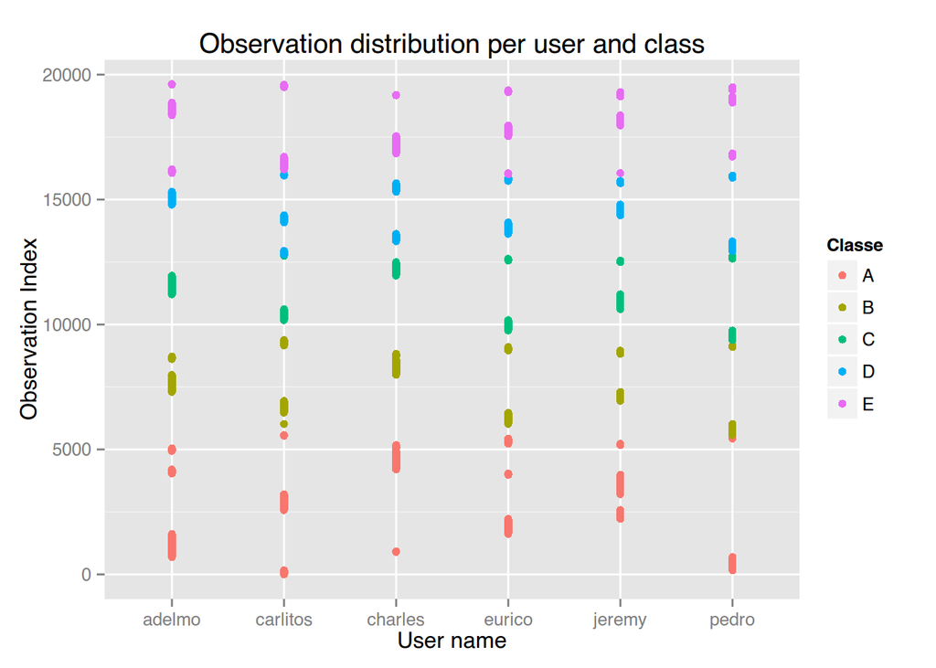

### Model fitting

After cleaning the data, I proceded with the model fitting on the available data. In order to assess the out-of-sample error of the methods, the data have been split into a training set, used for model fitting, and a test set, used for the assessment of the accuracy of the predictions (or, in other words the predictive error). Once the model have been generated, using caret's train function, I proceeded to the error estimation through the predict function and the generation of the confusion matrix.

### LDA, GBM, Bag of Trees

LDA, GBM and Bag of Trees models have been built by splitting the available data in the following way: 80% Training Set and 20% Test Set. With LDA and GBM, 10-fold cross validation has been repeated 3 times in order to assess the accuracy of the model. Bag of Trees model has been built using the default settings.

```r
inTrainingN <- createDataPartition(y=trainingData$classe,p=.8,list=F)
trainingN <- trainingData[inTrainingN,]
testingN <- trainingData[-inTrainingN,]

set.seed(17711771)

# 3 x 10-fold CV
fitControl <- trainControl(method = "repeatedcv", number = 10,  repeats = 3)

## Set up parallel processing
cluster <- makeCluster(detectCores()-1)
registerDoParallel(cluster)

modelLDA <- train(trainingN$classe~., data=trainingN,method="lda", trControl = fitControl, allowParallel=T)
bagTree <- train(trainingN$classe~., data=trainingN,method="treebag",allowParallel=T)
modelGBM <- train(trainingN$classe~., data=trainingN, method = "gbm",trControl = fitControl, allowParallel=T)

## turn off parallel processing
stopCluster(cluster)

# Prediction computations
predictionsLDA <- predict(modelLDA,newdata=testingN)
resultsLDA <- confusionMatrix(predictionsLDA,testingN$classe)

predictionsBag <- predict(bagTree,newdata=testingN)
resultsBag <- confusionMatrix(predictionsBag,testingN$classe)

predictionsGBM <- predict(modelGBM,newdata=testingN)
resultsGBM <- confusionMatrix(modelGBM,testingN$classe)
```

[Created by Pretty R at inside-R.org](http://www.inside-r.org/pretty-r)

### Random Forest

```r
# Split training-test set - Random Forest
inTrainingF <- createDataPartition(y=trainingData$classe,p=.6,list=F)
trainingF <- trainingData[inTrainingF,]
testingF <- trainingData[-inTrainingF,]

set.seed(17711771)

## Set up parallel processing - Random forest generation
cluster <- makeCluster(detectCores()-1)
registerDoParallel(cluster)

forest50 <- randomForest(trainingF$classe~., data=trainingF,ntree=50,importance=T,proximity=T,oob.prox=T,allowParallel=T)

## turn off parallel processing
stopCluster(cluster)

predictions <- predict(forest50,newdata=testingF)
results <- confusionMatrix(predictions,testingF$classe)
accuracy <- results$overall[1]

testData <- read.csv("pml-testing.csv");
predictionsFinal <- predict(forest50,newdata=testData)
```

[Created by Pretty R at inside-R.org](http://www.inside-r.org/pretty-r)

### Model results

The table summarizes the performances of the different methods on the training dataset. The Accuracy measure represent an estimation of 1-OutOfSampleError on the testing subset of the training dataset. By looking at this measure, the Random Forest of 50 trees, built with the default settings, has been selected since it showed the highest out of sample accuracy (i.e. the lowest out-of-sample error).

```
##          Accuracy     Kappa AccuracyLower AccuracyUpper AccuracyNull
## RF50    0.9982157 0.9977431     0.9963270     0.9992823    0.2844762
## LDA     0.7025236 0.6235467     0.6879438     0.7168011    0.2844762
## treebag 0.9966862 0.9958086     0.9943400     0.9982344    0.2844762
## GBM     0.9683915 0.9600157     0.9624286     0.9736425    0.2844762
```

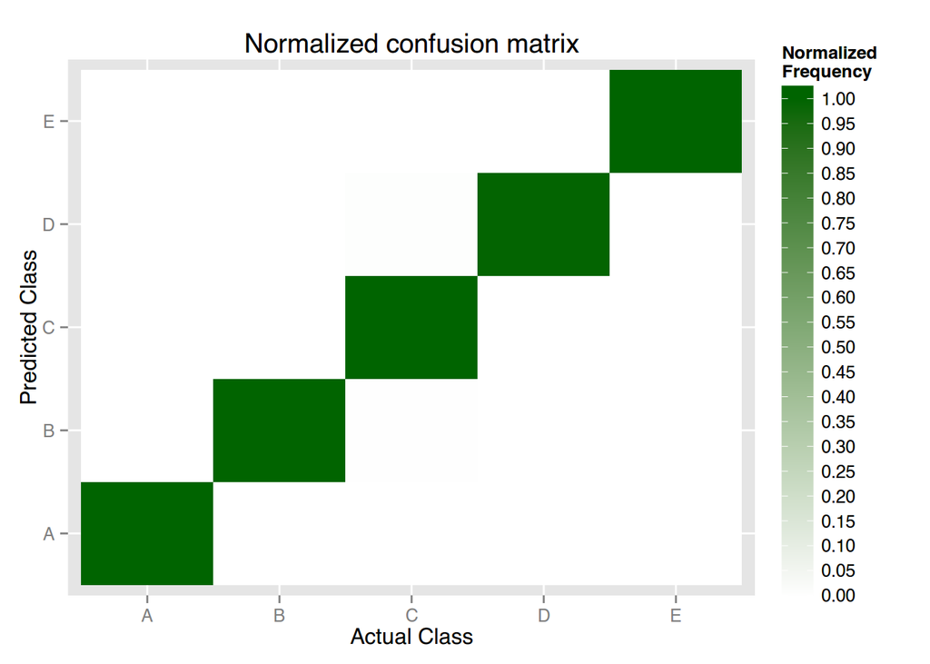

[output not shown]